# Caso: Donaciones de exalumnos

German Macías, Mauricio Herrera.

Programa. Maestría en Ciencia de Datos

Unidad de estudio. Modelos Estadísticos Aplicados

# 1 Contextualización.

El conjunto de datos proporcionado contiene información detallada sobre los exalumnos de alguna institución universitaria, abarcando varias dimensiones como género, año de graduación, estado civil, especialidad, próximo grado académico, donaciones anuales desde el año fiscal 2000 hasta el 2004, y asistencia a eventos. Los exalumnos están clasificados por género (masculino y femenino) y por año de graduación (1957, 1967, 1977, 1987 y 1997). Además, se incluye el estado civil de los exalumnos (casado, soltero, divorciado o viudo) y sus especialidades académicas, que varían desde Historia y Física hasta Psicología y Economía.

La base de datos también registra los grados académicos adicionales que los exalumnos han obtenido, como LLB, MS, MA, PHD, JD, MBA, MD, entre otros, o si no han obtenido ningún grado adicional. Las donaciones anuales de los exalumnos se registran para cada año fiscal del 2000 al 2004, mostrando una variabilidad significativa en las cantidades donadas. Este conjunto de datos permite un análisis integral de la demografía, antecedentes académicos, contribuciones financieras y el nivel de compromiso de los exalumnos con la institución

# 2 Variables de estudio.

El conjunto de datos incluye 11 variables. Las cuales se describen a continuación:

```
## 'data.frame':    1230 obs. of  11 variables:
##  $ Gender         : chr  "M" "M" "F" "M" ...
##  $ Class.Year     : int  1957 1957 1957 1957 1957 1957 1957 1957 1957 1957 ...
##  $ Marital.Status : chr  "M" "M" "M" "M" ...
##  $ Major          : chr  "History" "Physics" "Music" "History" ...
##  $ Next.Degree    : chr  "LLB" "MS" "NONE" "NONE" ...
##  $ FY04Giving     : num  2500 5000 5000 0 1000 0 0 100 100 0 ...
##  $ FY03Giving     : num  2500 5000 5000 5100 1000 0 0 100 100 0 ...
##  $ FY02Giving     : num  1400 5000 5000 200 1000 0 0 100 100 0 ...
##  $ FY01Giving     : num  12060 5000 5000 200 1005 ...
##  $ FY00Giving     : num  12000 10000 10000 0 1000 0 0 100 100 0 ...
##  $ AttendenceEvent: int  1 1 1 1 1 0 0 0 0 1 ...
```

```
##  [1] "Gender"          "Class.Year"      "Marital.Status"  "Major"
##  [5] "Next.Degree"     "FY04Giving"      "FY03Giving"      "FY02Giving"
##  [9] "FY01Giving"      "FY00Giving"      "AttendenceEvent"
```

| Variable | Código | Descripción | Escala | Naturaleza |
| --- | --- | --- | --- | --- |
| Género | Gender | Género del exalumno | Nominal | Categórica |
| Cohorte | Class Year | Año de graduación | Discreta | Numérica |
| Estado civil | Marital Status | Estado civil del exalumno | Nominal | Categórica |
| Carrera universitaria | Major | Área del conocimiento | Nominal | Categórica |
| Grados posteriores | Next Degree | Estudios superiores obtenidos | Nominal | Categórica |
| Donación 2004 | FY04Giving | Donación en el año 2004 (dólares) | Continua | Numérica |
| Donación 2003 | FY03Giving | Donación en el año 2003 (dólares) | Continua | Numérica |
| Donación 2002 | FY02Giving | Donación en el año 2002 (dólares) | Continua | Numérica |
| Donación 2001 | FY01Giving | Donación en el año 2001 (dólares) | Continua | Numérica |
| Donación 2000 | FY00Giving | Donación en el año 2000 (dólares) | Continua | Numérica |
| Asistencia | AttendenceEvent | Participación en eventos de recaudación | Discreta | Numérica |

Todas las variables juegan un papel importante para prever el éxito de futuras campañas de recaudación de fondos.

# 3 Análisis exploratorio.

- Código para visulizar los cinco primeros registros de la base de datos.

```r
# Visualizar los primeros cinco registros de la base.

head(data, 5)
```

```
##   Gender Class.Year Marital.Status   Major Next.Degree FY04Giving FY03Giving
## 1      M       1957              M History         LLB       2500       2500
## 2      M       1957              M Physics          MS       5000       5000
## 3      F       1957              M   Music        NONE       5000       5000
## 4      M       1957              M History        NONE          0       5100
## 5      M       1957              M Biology          MD       1000       1000
##   FY02Giving FY01Giving FY00Giving AttendenceEvent
## 1       1400      12060      12000               1
## 2       5000       5000      10000               1
## 3       5000       5000      10000               1
## 4        200        200          0               1
## 5       1000       1005       1000               1
```

- Código para identificar y eliminar datos faltantes de la base. Consolidación de una base de datos que no contenga valores perdidos.

```r
# Número de datos faltantes (NA).
sum(is.na(data))
```

```
## [1] 0
```

```r
colSums(is.na(data))# Número de datos faltantes por cada columna
```

```
##          Gender      Class.Year  Marital.Status           Major     Next.Degree
##               0               0               0               0               0
##      FY04Giving      FY03Giving      FY02Giving      FY01Giving      FY00Giving
##               0               0               0               0               0
## AttendenceEvent
##               0
```

```r
# Eliminar filas con datos faltantes.
# Asignar un nombre (por ejemplo, don1) al conjunto de datos que no tiene datos perdidos.
library(knitr)
library(kableExtra)
# Utilizar la base don1 para los anÃ¡lisis que siguen.
don1 <- na.omit(data)

summary_table <- summary(don1)

# Mostrar la tabla con kableExtra
kable(summary_table) %>%
  kable_styling(bootstrap_options = c("striped", "hover", "condensed", "responsive"),
                full_width = F)
```

|  | Gender | Class.Year | Marital.Status | Major | Next.Degree | FY04Giving | FY03Giving | FY02Giving | FY01Giving | FY00Giving | AttendenceEvent |
| --- | --- | --- | --- | --- | --- | --- | --- | --- | --- | --- | --- |
|  | Length:1230 | Min. :1957 | Length:1230 | Length:1230 | Length:1230 | Min. : 0.0 | Min. : 0.0 | Min. : 0.0 | Min. : 0.0 | Min. : 0.0 | Min. :0.0000 |
|  | Class :character | 1st Qu.:1967 | Class :character | Class :character | Class :character | 1st Qu.: 0.0 | 1st Qu.: 0.0 | 1st Qu.: 0.0 | 1st Qu.: 0.0 | 1st Qu.: 0.0 | 1st Qu.:0.0000 |
|  | Mode :character | Median :1987 | Mode :character | Mode :character | Mode :character | Median : 0.0 | Median : 0.0 | Median : 0.0 | Median : 0.0 | Median : 0.0 | Median :1.0000 |
|  | NA | Mean :1981 | NA | NA | NA | Mean : 159.4 | Mean : 241.5 | Mean : 133.5 | Mean : 276.5 | Mean : 169.2 | Mean :0.6041 |
|  | NA | 3rd Qu.:1997 | NA | NA | NA | 3rd Qu.: 75.0 | 3rd Qu.: 75.0 | 3rd Qu.: 51.0 | 3rd Qu.: 75.0 | 3rd Qu.: 60.0 | 3rd Qu.:1.0000 |
|  | NA | Max. :1997 | NA | NA | NA | Max. :14655.2 | Max. :58785.5 | Max. :11187.3 | Max. :161370.1 | Max. :21000.0 | Max. :1.0000 |

```r
# Usar la función dim() para identificar la dimensión de la nueva base de datos.

dim(don1)
```

```
## [1] 1230   11
```

- Realizar coerción de variables.

```r
estructura <- data.frame(
  Variable = names(don1),
  Tipo = sapply(don1, class)
)

kable(estructura, col.names = c("Variable", "Tipo de Dato")) %>%
  kable_styling(bootstrap_options = c("striped", "hover", "condensed", "responsive"),
                full_width = F)
```

|  | Variable | Tipo de Dato |
| --- | --- | --- |
| Gender | Gender | factor |
| Class.Year | Class.Year | character |
| Marital.Status | Marital.Status | character |
| Major | Major | character |
| Next.Degree | Next.Degree | character |
| FY04Giving | FY04Giving | numeric |
| FY03Giving | FY03Giving | numeric |
| FY02Giving | FY02Giving | numeric |
| FY01Giving | FY01Giving | numeric |
| FY00Giving | FY00Giving | numeric |
| AttendenceEvent | AttendenceEvent | logical |

# 4 Análisis descriptivo.

- Construir una tabla o un gráfico que permita saber cuántos exalumnos se tienen por cohorte. Interpreten a la luz del contexto.

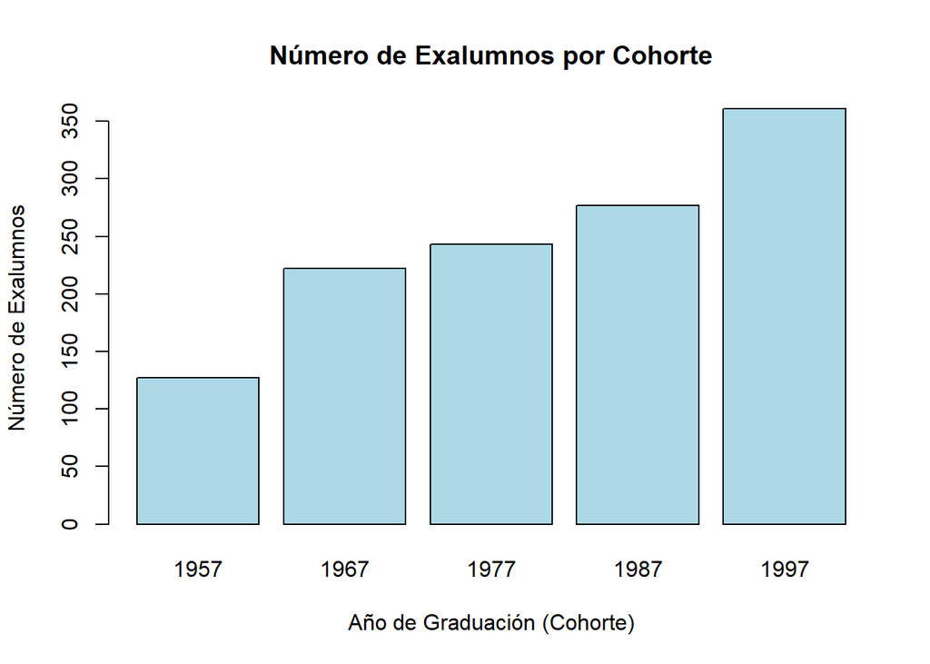

```r
# Tabla o gráfico del número de exalumnos por cohorte

tabla_cohorte <- table(don1$Class.Year)
# Gráfico de barras con barplot
barplot(tabla_cohorte,
        main = "Número de Exalumnos por Cohorte",
        xlab = "Año de Graduación (Cohorte)",
        ylab = "Número de Exalumnos",
        col = "lightblue",
        border = "black")
```

```r
# libreria  knitr

library(knitr)

# tabla con knitr::kable
tabla_cohorte <- table(don1$Class.Year)
kable(tabla_cohorte, col.names = c("Cohorte (Año de Graduación)", "Número de Exalumnos"),
      caption = "Número de Exalumnos por Cohorte",
      align = 'c')
```

Número de Exalumnos por Cohorte

| Cohorte (Año de Graduación) | Número de Exalumnos |
| --- | --- |
| 1957 | 127 |
| 1967 | 222 |
| 1977 | 243 |
| 1987 | 277 |
| 1997 | 361 |

- Crear una nueva variable con el nombre **Tgiving**. Esta variable corresponde al total de las contribuciones de cada graduado. Calculen los estadísticos descriptivos (media, mediana, desviación, coeficiente de variación, mínimo y máximo) de esta variable. Utilicen funciones como **round()**, **data.frame()** y **cbind()** (u otras que ustedes consulten) para presentar los resultados redondeados a dos cifras decimales y organizados en una tabla. Interpreten los resultados a la luz del contexto.

Estadísticos Descriptivos de la Variable TGiving

| Estadístico | Valor |
| --- | --- |
| Media | 980.04 |
| Mediana | 75.00 |
| Desviación estándar | 6670.77 |
| Coeficiente de Variación | 6.81 |
| Mínimo | 0.00 |
| Máximo | 171870.06 |

- Determinar los deciles correspondientes a las observaciones de la variable contribuciones totales (variable **TGiving**) e interpreten los resultados que obtienen.

```r
# Cálculo de deciles

deciles <- quantile(don1$Tgiving, probs = seq(0, 1, 0.1), na.rm = TRUE)

# Convertir los deciles en un data.frame para mejor visualización
tabla_deciles <- data.frame(
  Decil = paste0(seq(0, 100, 10), "%"),
  Valor = round(deciles, 2)
)


kable(tabla_deciles, col.names = c("Decil", "Valor ($)"),
      caption = "Deciles de la variable TGiving (Contribuciones Totales)",
      row.names = FALSE,
      align = 'c')
```

Deciles de la variable TGiving (Contribuciones Totales)

| Decil | Valor ($) |
| --- | --- |
| 0% | 0.0 |
| 10% | 0.0 |
| 20% | 0.0 |
| 30% | 0.0 |
| 40% | 25.0 |
| 50% | 75.0 |
| 60% | 150.8 |
| 70% | 275.0 |
| 80% | 554.2 |
| 90% | 1050.0 |
| 100% | 171870.1 |

- Tener en cuenta que hay un número considerable de exalumnos que no han contribuido y unos pocos que han realizado aportes muy altos. Por ello, es pertinente excluir del análisis contribuciones totales que sean $0 o superiores a $4000. Esto permite focalizar el análisis en las donaciones más frecuentes de los exalumnos. Construyan un histograma junto con la función de densidad, para visualizar las contribuciones totales (variable **TGiving**) excluyendo los valores descritos. Interpreten los resultados a la luz del contexto.

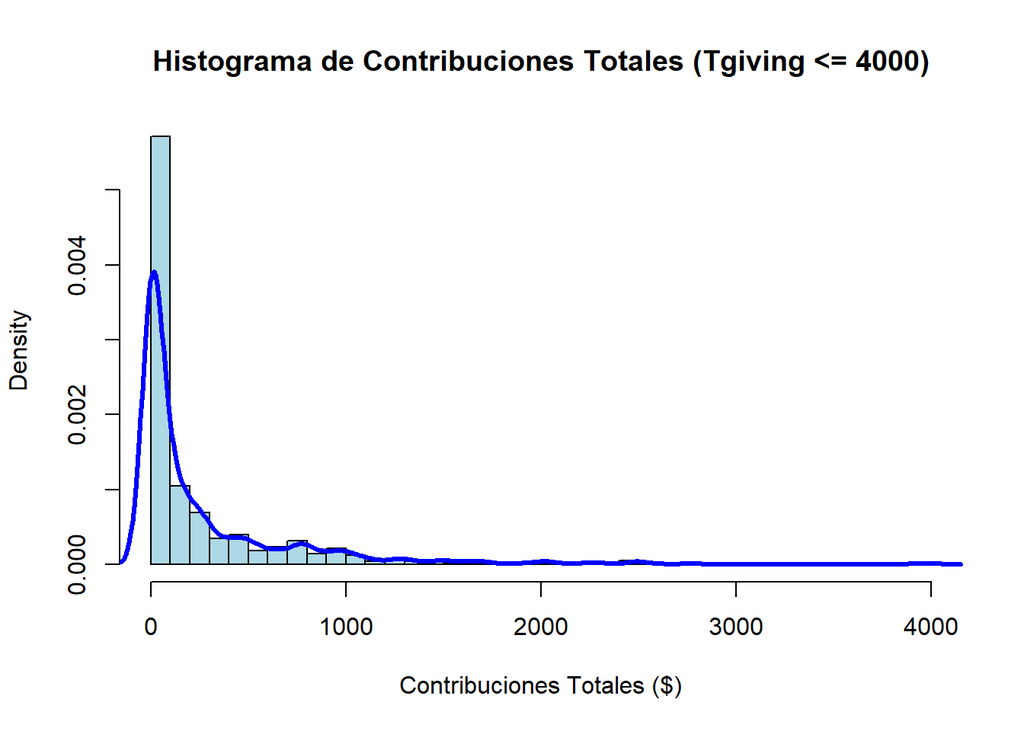

```r
# Histograma para las constribuciones totales.
# Sugerencia: Ir a https://r-coder.com/histograma-r/ para ver modificaciones del gráfico.

# Filtrar las contribuciones menores o iguales a 4000
tgiving_filtrado <- don1$Tgiving[don1$Tgiving <= 4000]

# Crear el histograma con densidad superpuesta
hist(tgiving_filtrado,
     breaks = 30,
     main = "Histograma de Contribuciones Totales (Tgiving <= 4000)",
     xlab = "Contribuciones Totales ($)",
     col = "lightblue",
     border = "black",
     probability = TRUE)

# Agregar la curva de densidad
lines(density(tgiving_filtrado), col = "blue", lwd = 3)
```

- Describir las características de los exalumnos que han realizado las contribuciones más altas durante el 2000-2004. Para ello seleccionen los egresados que hicieron una contribución total (variable **TGiving**) de al menos $20000 durante el periodo de interés.

```r
# Donantes con las contribuciones más altas.

donantes_altas <- don1[don1$Tgiving >= 20000, ]#los exalumnos que hicieron contribuciones >= $20,000
kable(donantes_altas, col.names = c("Género", "Año Graduación", "Estado Civil", "Carrera",
                                    "Próximo Grado", "Donación 2004", "Donación 2003",
                                    "Donación 2002", "Donación 2001", "Donación 2000",
                                    "Eventos Asistidos", "Contribución Total"),
      caption = "Donantes con Contribuciones Altas", align = 'c')
```

Donantes con Contribuciones Altas

|  | Género | Año Graduación | Estado Civil | Carrera | Próximo Grado | Donación 2004 | Donación 2003 | Donación 2002 | Donación 2001 | Donación 2000 | Eventos Asistidos | Contribución Total |
| --- | --- | --- | --- | --- | --- | --- | --- | --- | --- | --- | --- | --- |
| 1 | M | 1957 | M | History | LLB | 2500.00 | 2500.0 | 1400.00 | 12060.00 | 12000.00 | TRUE | 30460.00 |
| 2 | M | 1957 | M | Physics | MS | 5000.00 | 5000.0 | 5000.00 | 5000.00 | 10000.00 | TRUE | 30000.00 |
| 3 | F | 1957 | M | Music | NONE | 5000.00 | 5000.0 | 5000.00 | 5000.00 | 10000.00 | TRUE | 30000.00 |
| 99 | M | 1957 | M | Mathematics-Physics | NONE | 0.00 | 2500.0 | 2000.00 | 161370.06 | 6000.00 | TRUE | 171870.06 |
| 105 | M | 1957 | M | History | PHD | 11505.84 | 10000.0 | 10000.00 | 0.00 | 20000.00 | TRUE | 51505.84 |
| 123 | M | 1957 | W | Economics-Business | MBA | 5000.00 | 58785.5 | 8031.00 | 12878.14 | 6131.24 | TRUE | 90825.88 |
| 132 | M | 1967 | M | Speech (Drama, etc.) | JD | 14655.25 | 14776.0 | 11187.26 | 14466.81 | 16959.99 | TRUE | 72045.31 |
| 135 | M | 1967 | M | History | JD | 11500.00 | 26500.0 | 1000.00 | 2500.00 | 1000.00 | TRUE | 42500.00 |
| 471 | F | 1977 | D | Economics | JD | 1000.00 | 1500.0 | 6000.00 | 2000.00 | 21000.00 | TRUE | 31500.00 |
| 486 | M | 1977 | M | Economics | MBA | 6500.00 | 7000.0 | 6000.00 | 8000.00 | 8860.90 | TRUE | 36360.90 |

- Elaborar diagramas de caja que permita comparar la donación total (variable **TGiving**) durante los 5 años discriminando por cohorte, género, estado civil y asistencia a eventos de recaudación de fondos. Con la opción **outline** omitan las observaciones periféricas (datos atípicos, es decir, aquellos donantes que contribuyen generosamente). Comparen los cuatro gráficos, destaquen diferencias y similitudes entre grupos.

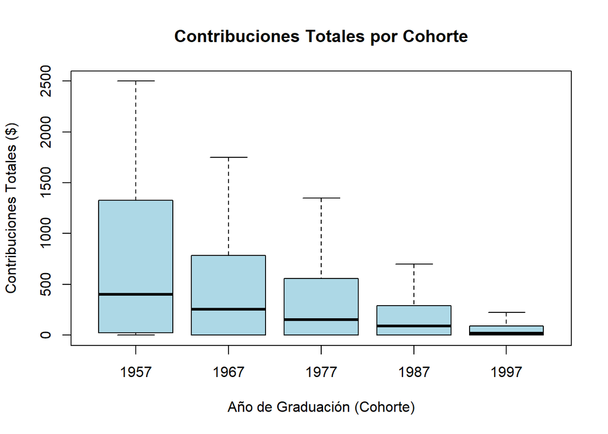

```r
# Diagrama de caja para la variable contribuciones totales por chorte.
# Sugerencia: Ir a https://r-coder.com/boxplot-r/ para ver modificaciones del grÃ¡fico.
# Diagrama de caja para contribuciones totales por cohorte
boxplot(Tgiving ~ Class.Year, data = don1, outline = FALSE,
        main = "Contribuciones Totales por Cohorte",
        xlab = "Año de Graduación (Cohorte)",
        ylab = "Contribuciones Totales ($)",
        col = "lightblue")
```

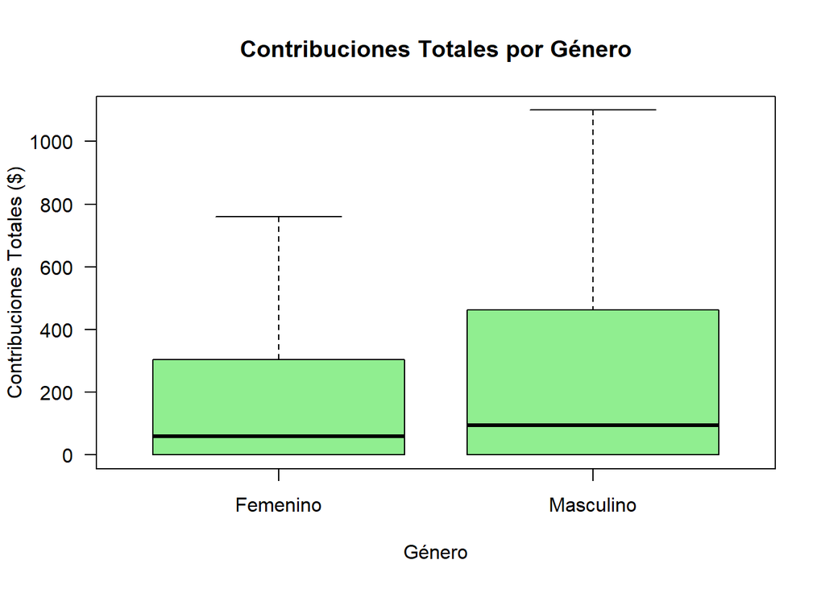

```r
# Diagrama de caja para la variable contribuciones totales por género.
# Sugerencia: Ir a https://r-charts.com/es/r-base/ejes/ para ver cambio en las etiquetas de los ejes.
boxplot(Tgiving ~ Gender, data = don1, outline = FALSE,
        main = "Contribuciones Totales por Género",
        xlab = "Género",
        ylab = "Contribuciones Totales ($)",
        col = "lightgreen", axes = FALSE)


axis(1, at = 1:2, labels = c("Femenino", "Masculino"))  # Personalizar los ejes
axis(2, las = 2)  # Eje Y con etiquetas rotadas


box() # marco
```

[figure not shown]

```r
# Diagrama de caja para la variable contribuciones totales por estado civil

boxplot(Tgiving ~ Marital.Status, data = don1, outline = FALSE,
        main = "Contribuciones Totales por Estado Civil",
        xlab = "Estado Civil",
        ylab = "Contribuciones Totales ($)",
        col = "lightblue", axes = FALSE)  # Desactivar los ejes por defecto


axis(1, at = 1:4, labels = c("Soltero", "Casado", "Divorciado", "Viudo"))  # Personalizar los ejes
axis(2, las = 2)  # Eje Y con etiquetas rotadas


box() # marco
```

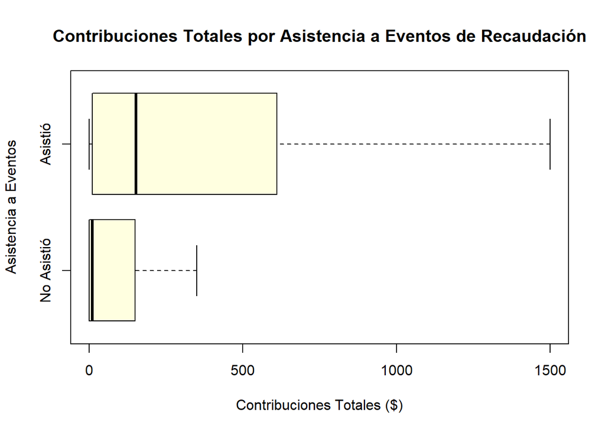

```r
# Diagrama de caja para la variable contribuciones totales por asisitencia a eventos de recaudación de fondos.

boxplot(Tgiving ~ AttendenceEvent, data = don1, outline = FALSE,
        horizontal = TRUE,  # Diagrama horizontal
        main = "Contribuciones Totales por Asistencia a Eventos de Recaudación",
        xlab = "Contribuciones Totales ($)",
        ylab = "Asistencia a Eventos",
        col = "lightyellow",  # Cambiar el color de las cajas
        axes = FALSE)

axis(2, at = 1:2, labels = c("No Asistió", "Asistió"))  # Etiquetas personalizadas para el eje Y
axis(1, las = 1)  # Eje X con etiquetas horizontales


box()
```

- Construir una tabla que de cuenta del número de estudiantes y el promedio del total de contribuciones (variable **TGiving**) por carrera universitaria. ¿Cuáles son las carreras que tienen un mayor número de exalumnos en la base de datos? ¿cuáles son las que tienen una contribución total promedio más alta? Para calcular promedio por grupos pueden utilizar la función **tapply()**.

```r
# Sugerencia: Ir a https://r-coder.com/tapply-r/ para ver cálculo de medidas por grupos.


num_exalumnos <- table(don1$Major)# Calcular el número de exalumnos por carrera

# Calcular el promedio de contribuciones por carrera
promedio_contribuciones <- tapply(don1$Tgiving, don1$Major, mean, na.rm = TRUE)


tabla_carrera_contribuciones <- data.frame(
  Carrera = names(num_exalumnos),
  Num_Exalumnos = as.vector(num_exalumnos),
  Promedio_Contribuciones = round(as.vector(promedio_contribuciones), 2)
)# Combinar ambos resultados


tabla_carrera_contribuciones
```

```
##                      Carrera Num_Exalumnos Promedio_Contribuciones
## 1           American Studies            29                  451.28
## 2               Anthropology            44                  164.25
## 3                        Art            39                  164.08
## 4                    Biology           115                  551.00
## 5                  Chemistry            63                  421.84
## 6          Chemistry-Zoology             3                11083.33
## 7                    Chinese             2                  132.50
## 8                   Classics             9                  767.00
## 9     Comparative Literature             2                    0.00
## 10          Computer Science             4                  737.00
## 11                 Economics            87                 1166.91
## 12        Economics-Business            24                 4334.66
## 13  Economics-Regional Stds.             2                  350.00
## 14                 Education             6                  473.67
```

[output cut: 32 more lines]

- Crear una variable indicadora (pueden denominarla **TGivingIND**) que clasifique los exalumnos en contribuyentes (1) y no contribuyentes (0). Utilizando esta variable elaboren un mosaico para visualizar la proporción de contribuyentes por cohorte y otro para visualizar la proporción según la asistencia a eventos. Interpreten lo que observan en estos gráficos.

```r
# Crear la variable indicadora.

don1$TgivingIND <- ifelse(don1$Tgiving > 0, 1, 0)


head(don1$TgivingIND)# Verificar las primeras filas de la nueva variable
```

```
## [1] 1 1 1 1 1 0
```

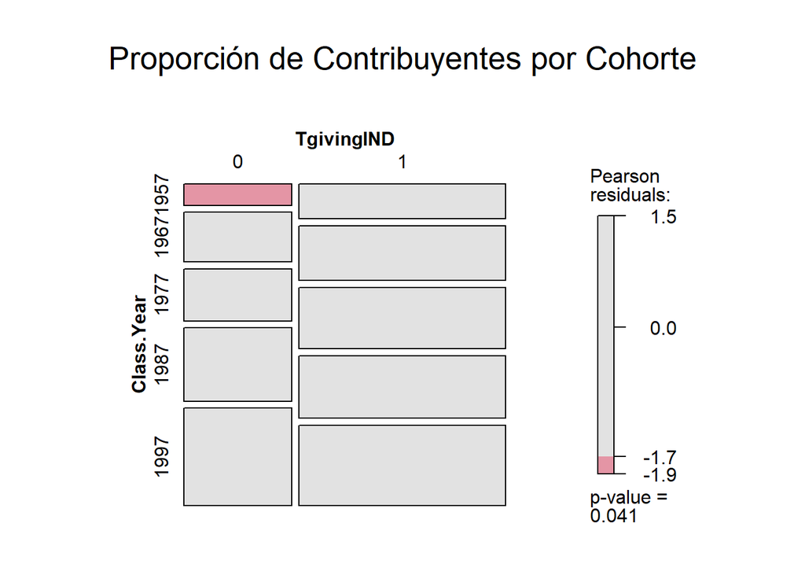

```r
# Mosaico patra la proporción de contribuyentes por cohorte.

#install.packages("vcd")
#install.packages("RColorBrewer")
library(vcd)
library(RColorBrewer)
# Crear una paleta de colores
mosaic_colors <- brewer.pal(3, "Set3")

# Crear el mosaico con colores personalizados
mosaic(~ TgivingIND + Class.Year, data = don1,
       main = "Proporción de Contribuyentes por Cohorte",
       shade = TRUE,
       gp = shading_max,
       direction = c("v", "h"),
       legend = TRUE,
       highlighting_fill = mosaic_colors)
```

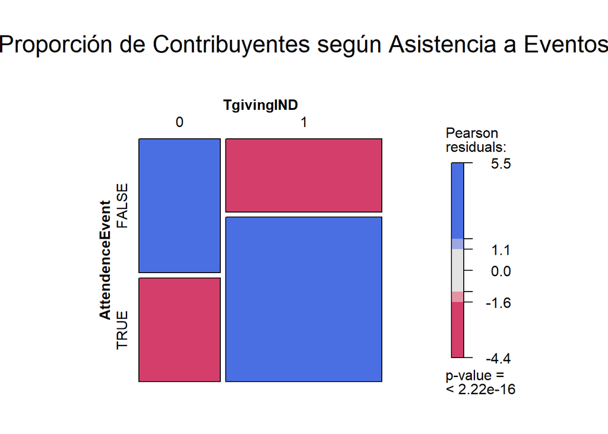

```r
# Mosaico para la proporción de contribuyentes según asistencia a eventos.
# Crear el mosaico para contribuyentes según asistencia a eventos
mosaic(~ TgivingIND + AttendenceEvent, data = don1,
       main = "Proporción de Contribuyentes según Asistencia a Eventos",
       shade = TRUE,
       gp = shading_max,
       direction = c("v", "h"),
       legend = TRUE)
```

# 5 Discusión.

A partir del análisis realizado, podemos concluir que los exalumnos que asisten a eventos organizados por la universidad tienen una mayor predisposición a realizar contribuciones significativas. Las carreras relacionadas con disciplinas como Historia y Ciencias Físicas han mostrado una participación considerable en las donaciones, lo que señala una oportunidad estratégica para focalizar esfuerzos en estos grupos. En vista de los datos, se recomienda que las futuras campañas de recaudación fortalezcan la conexión con los exalumnos a través de eventos, los cuales parecen tener un impacto positivo en la decisión de donar.

Asimismo, es importante considerar algunos aspectos que no han sido plenamente examinados en el análisis. Por ejemplo, la participación de los exalumnos en redes y actividades extracurriculares durante su tiempo en la universidad puede ser un indicador relevante de compromiso futuro. Esto permitiría una segmentación más detallada de los potenciales donantes, proporcionando una visión más completa que facilite la personalización de las estrategias de recaudación. Incorporar esta información en el análisis podría aumentar la eficacia de las campañas.

Por último, para identificar con mayor precisión a los exalumnos con alto potencial de donación, sería valioso incluir variables adicionales como la ubicación geográfica, nivel de ingresos y el grado de participación en las actividades de la universidad después de su graduación. Estos datos permitirían una segmentación más profunda y ofrecerían información crucial para definir estrategias de comunicación y acercamiento más efectivas. La frecuencia de interacción con la universidad también puede servir como un fuerte predictor de futuras contribuciones, lo que resulta clave para optimizar las decisiones en torno a las próximas campañas de recaudación.